# Problem Set #1: Exploring Wage Differences in the U.S. Early Care and Education Workforce

2026-08-03

```r
## Set up
library(dplyr)
library(tidyr)
library(tidyverse)
```

```r
library(forcats)
library(ggplot2)


describe_num <- function(x) {
  x <- x[!is.na(x)]
  data.frame(
    n = length(x), mean = mean(x), sd = sd(x), median = median(x),
    min = min(x), max = max(x), range = max(x) - min(x),
    skew = mean((x - mean(x))^3) / sd(x)^3
  )
}

freq_table <- function(x) {
  x <- x[!is.na(x)]
  tab <- table(x)
  data.frame(category = names(tab), n = as.integer(tab),
             pct = round(100 * as.integer(tab) / length(x), 1))
}


## Load data
load("~/UChicago_Student/2_Data_For_Policy_Analys_-_Mgmt/Data/37941-0005-Data.rda")
nsece_raw <- da37941.0005

## Subset to variables
nsece <- nsece_raw %>%
  select(
    WF9_WORK_WAGE,
    WF9_WORK_ROLE,
    WF9_WORK_YRS,
    WF9_CHAR_HISP,
    WF9_CHAR_RACE,
    WF9_CHAR_EDUC,
    WF9_CHAR_GENDER
  )

## Rename variables
nsece <- nsece %>%
  rename(
    wage       = WF9_WORK_WAGE,
    role       = WF9_WORK_ROLE,
    yrs_worked = WF9_WORK_YRS,
    hispanic   = WF9_CHAR_HISP,
    race       = WF9_CHAR_RACE,
    educ       = WF9_CHAR_EDUC,
    gender     = WF9_CHAR_GENDER
  )

## Missing data

nsece %>%
  summarise(across(everything(), ~ sum(is.na(.x)))) %>%
  pivot_longer(everything(), names_to = "variable", values_to = "n_missing") %>%
  mutate(pct_missing = round(100 * n_missing / nrow(nsece), 1))
```

```
## # A tibble: 7 × 3
##   variable   n_missing pct_missing
##   <chr>          <int>       <dbl>
## 1 wage             922        17.8
## 2 role             484         9.3
## 3 yrs_worked       517        10
## 4 hispanic         611        11.8
## 5 race             951        18.3
## 6 educ             507         9.8
## 7 gender           546        10.5
```

```r
## Recode
# role, hispanic, race,gender: nominal -> leace as unordered factors (already are)
# edu, yrs_worked: ordinal -> set explixit order so later tests treat them correctly


nsece <- nsece %>%
  mutate(
    educ = factor(educ, levels = c(
      "(1) Less than High School",
      "(3) GED or high school equivalency",
      "(4) High school graduate",
      "(5) Some college credit but no degree",
      "(6) Associate degree (AA, AS)",
      "(7) Bachelor's degree (BA, BS, AB)",
      "(8) Graduate or professional degree"
    ), ordered = TRUE),

    yrs_worked = factor(yrs_worked, levels = c(
      "(01) Less than half a year (0-6 months)", "(02) 7-12 months",
      "(03) 1 year", "(04) 2 years", "(05) 3 years", "(06) 4 years",
      "(07) 5 years", "(08) 6 years", "(09) 7 years", "(10) 8 years",
      "(11) 9 years", "(12) 10 years", "(13) 11 to 15 years",
      "(14) 16 to 20 years", "(15) 21 to 25 years", "(16) 26 or more years"
    ), ordered = TRUE)
  )

## Level of measurment/variable type

# wage        -> interval/ratio, continuous   (hourly dollar amount; true zero)
# role        -> nominal, discrete            (3 categories: Aide/asst, Teacher/lead, Other)
# yrs_worked  -> ORDINAL, discrete            (16 bins of unequal width, e.g. "11 to 15 years" -
#                                               NOT a raw count, so treat as ordinal, not ratio)
# hispanic    -> nominal, discrete            (binary)
# race        -> nominal, discrete            (4 categories: White, Black, Asian, Other)
# educ        -> ORDINAL, discrete            (7 ranked categories, unequal spacing)
# gender      -> nominal, discrete            (binary)

## Descriptive Statistics
```

**Question 1: Data Preparation and Descriptive Statistics**

*The analytic sample was drawn from the NSECE 2019 Questionnaire (N=5,192) and subset to seven variables: hourly wage, staff role, years worked in the program, Hispanic/Latino ethnicity, race, educational attainment, and gender. Each variable was classified by level of measurement to guide the choice of descriptive statistics and, layer, inferential tests.*

**Hourly wage** *is a continous interval/ratio variable. Among the 4,270 respondents with vald wage data (17.8% missing), the mean hourly wage was $15.33 (SD = $10.65), while the median was noticeably lower at $12.83, with a range from $1.29 to $107.50. As shown in Figure 1, the distribution is strongly right-skewed (skewness ~ 5), with a long tail of high earners pulling the mean above the median. The median is therefore the more representiative measure of central tendency for this variable, and it will also be preferred in wage-difference tests where the distributional assumptions of mean-based tests may not hold.*

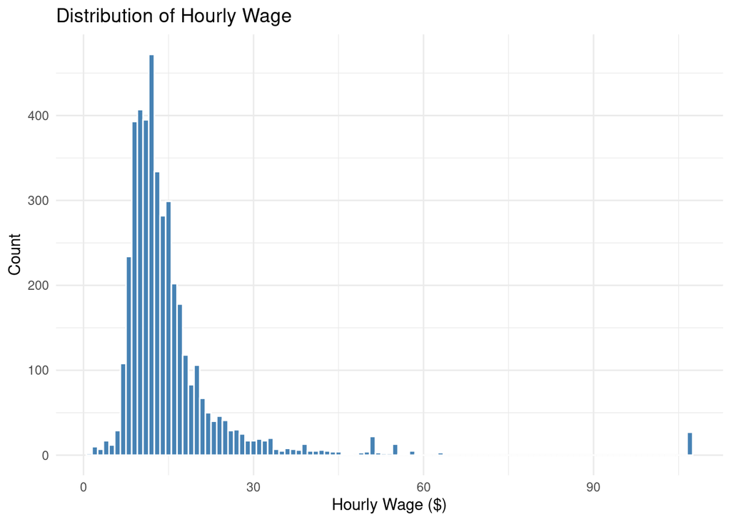

```r
# -- Wage (continuous) -- Figure 1. Distribution of hourly wage.


ggplot(nsece, aes(x = wage)) +
  geom_histogram(binwidth = 1, fill = "steelblue", color = "white", na.rm = TRUE) +
  labs(title = "Distribution of Hourly Wage", x = "Hourly Wage ($)", y = "Count") +
  theme_minimal()
```

**Staff role** *is a nominal, discrete variable with three categories. As Figure 2 shows, the workforce sample was composed primarily of teachers/lead teachers (65.4%) and aides/assistant teachers (34.3%), with an “other/undetermined” category accounting for a negligible 0.4% (n=18)*

```r
# -- Role (nominal) -- Figure 2. Distribution of staff role.
freq_table(nsece$role)
```

```
##                                   category    n  pct
## 1            (1) Aide or assistant teacher 1611 34.2
## 2 (2) Teacher, instructor, or lead teacher 3079 65.4
## 3                   (3) Other/undetermined   18  0.4
```

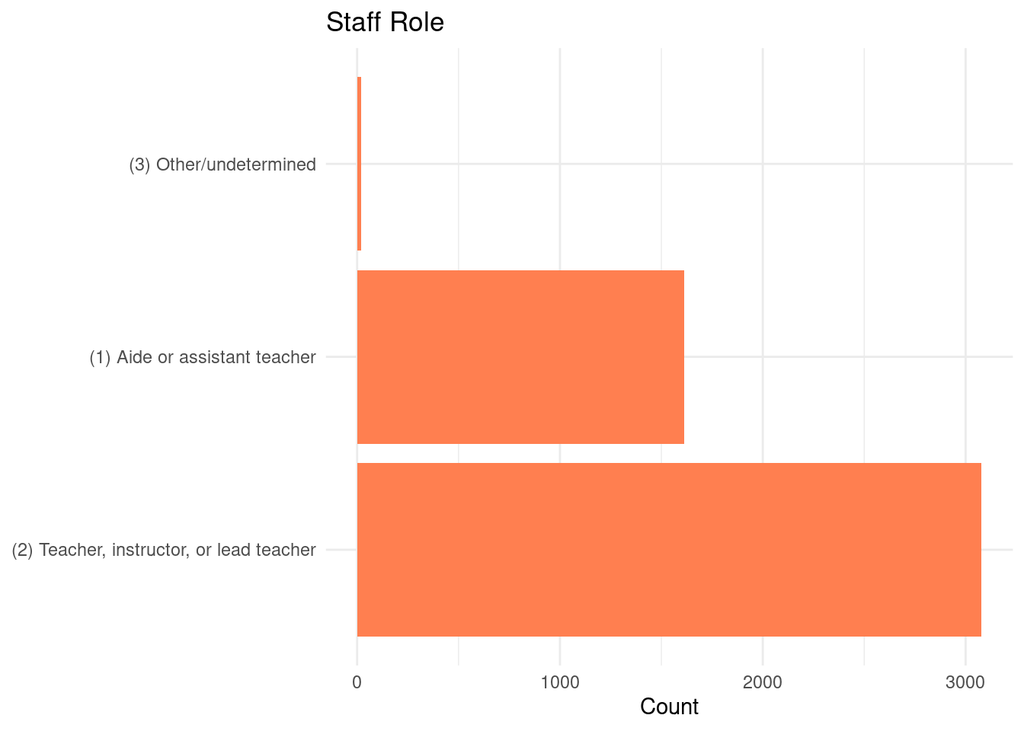

```r
ggplot(nsece %>% filter(!is.na(role)), aes(x = fct_infreq(role))) +
  geom_bar(fill = "coral") +
  labs(title = "Staff Role", x = NULL, y = "Count") +
  coord_flip() +
  theme_minimal()
```

```r
# -- Years worked (ordinal) -- Figure 3. Distribution of years worked in program.
freq_table(nsece$yrs_worked)
```

```
##                                   category   n  pct
## 1  (01) Less than half a year (0-6 months) 463  9.9
## 2                         (02) 7-12 months 396  8.5
## 3                              (03) 1 year 662 14.2
## 4                             (04) 2 years 519 11.1
## 5                             (05) 3 years 429  9.2
## 6                             (06) 4 years 313  6.7
## 7                             (07) 5 years 272  5.8
## 8                             (08) 6 years 196  4.2
## 9                             (09) 7 years 150  3.2
## 10                            (10) 8 years 122  2.6
## 11                            (11) 9 years  88  1.9
## 12                           (12) 10 years 170  3.6
## 13                     (13) 11 to 15 years 395  8.4
## 14                     (14) 16 to 20 years 262  5.6
## 15                     (15) 21 to 25 years 124  2.7
## 16                   (16) 26 or more years 114  2.4
```

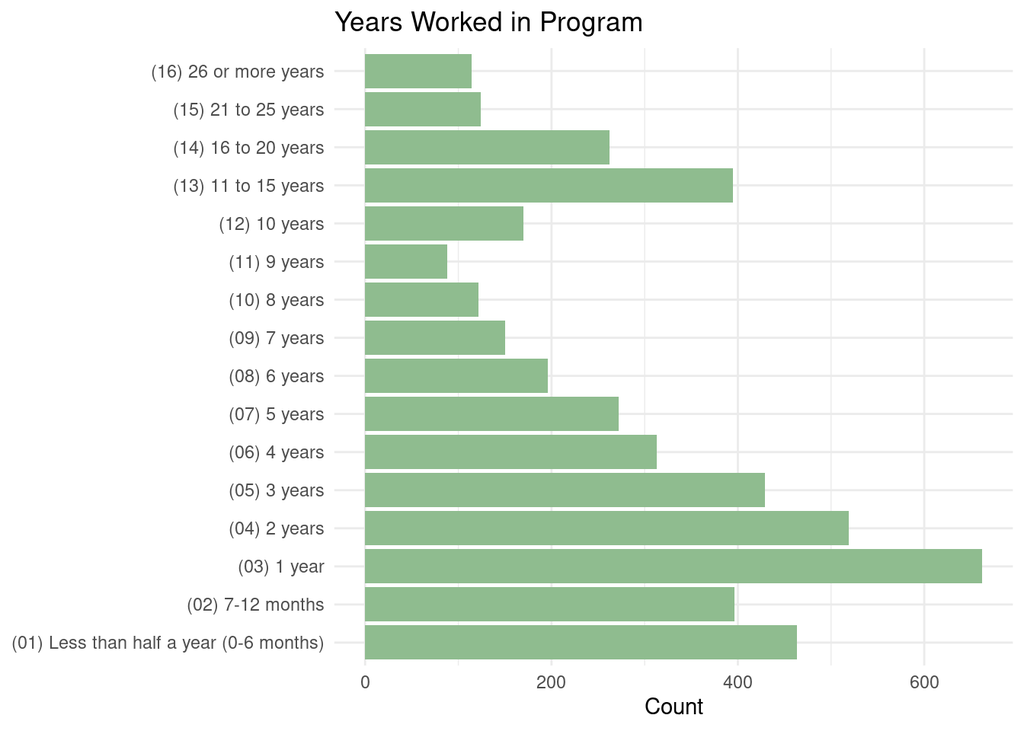

```r
ggplot(nsece %>% filter(!is.na(yrs_worked)), aes(x = yrs_worked)) +
  geom_bar(fill = "darkseagreen") +
  labs(title = "Years Worked in Program", x = NULL, y = "Count") +
  coord_flip() +
  theme_minimal()
```

**Hispanic/Latino ehtnicity** *and* **gender** *are both nominal, discrete, binary variables. Approximately 24.4% of respondents identified as Hispanic or Latino. The sample is heavily skewed by gender, with 97.6% identifying as female and only 2.4% male (n = 112)- a notable imbalance to keep in mind for any later gender comparison, since the male subgroup is small.*

```r
# -- Hispanic/Latino (nominal) --
freq_table(nsece$hispanic)
```

```
##                     category    n  pct
## 1     (1) Hispanic or Latino 1119 24.4
## 2 (2) Not Hispanic or Latino 3462 75.6
```

```r
# -- Gender (nominal) --
freq_table(nsece$gender)
```

```
##     category    n  pct
## 1   (1) Male  112  2.4
## 2 (2) Female 4534 97.6
```

**Race** *is a nominal, dsicrete variable with four categories. (18.3% missing). As shown in figure 4, the sample was predominantly White (66.6%), followed by Black or African American (23.4%), Other (5.1%), and Asian (5.0%).* *Note that the race variable is derived from a survey item allowing respondents to select multiple races, and respondents selecting more than one race were coded into the ‘other’ category, so racial comparisons in this analysis reflect single-race groupings versus a herterogenous ‘other’ category, not a full accounting of racial identification.*

```r
# -- Race (nominal) -- Figure 4. Distribution of race.
freq_table(nsece$race)
```

```
##                             category    n  pct
## 1                     (1) White Only 2825 66.6
## 2 (2) Black or African American Only  991 23.4
## 3                     (3) Asian Only  210  5.0
## 4                          (8) Other  215  5.1
```

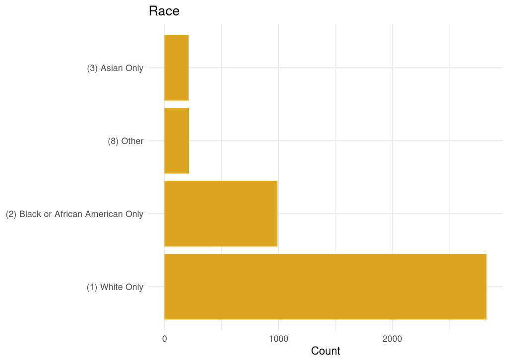

```r
ggplot(nsece %>% filter(!is.na(race)), aes(x = fct_infreq(race))) +
  geom_bar(fill = "goldenrod") +
  labs(title = "Race", x = NULL, y = "Count") +
  coord_flip() +
  theme_minimal()
```

**Educational attainment** *is an ordinal, discrete variable with seven ranked categories. Figure 5 shows a distribution concentrated in the middle categories, with 27.3% reporting some college credit but no degree, 24.9% holding a BA degree, and 17.8% holding an associate degree. Very few respondents (1.8%) reported less than a high school education.*

```r
# -- Education (ordinal) -- Figure 5. Distribution of educational attainment.
freq_table(nsece$educ)
```

```
##                                category    n  pct
## 1             (1) Less than High School   85  1.8
## 2    (3) GED or high school equivalency  126  2.7
## 3              (4) High school graduate  769 16.4
## 4 (5) Some college credit but no degree 1279 27.3
## 5         (6) Associate degree (AA, AS)  834 17.8
## 6    (7) Bachelor's degree (BA, BS, AB) 1168 24.9
## 7   (8) Graduate or professional degree  424  9.1
```

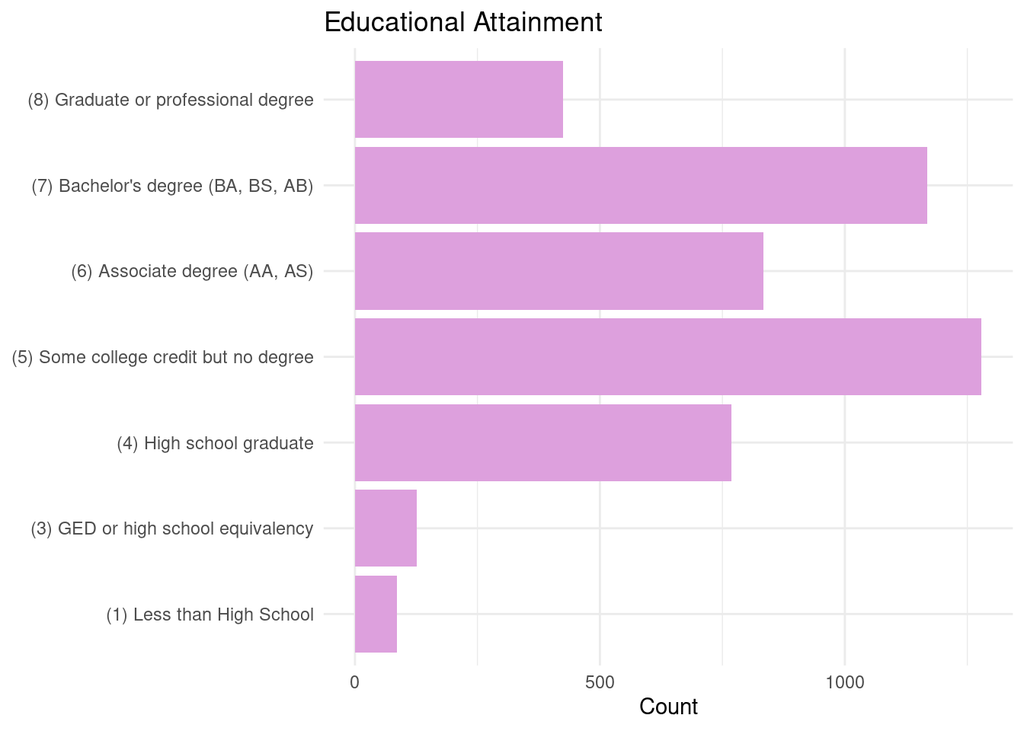

```r
ggplot(nsece %>% filter(!is.na(educ)), aes(x = educ)) +
  geom_bar(fill = "plum") +
  labs(title = "Educational Attainment", x = NULL, y = "Count") +
  coord_flip() +
  theme_minimal()
```

*Missing data ranged from about 9% (role, education) to 18% (wage,race). A cross-check of wage missingness by staff role found no evidence of concentration in a particular group (missingness ranged narrowly from 8.8% to 11.1% across roles), suggesting the missingness is unlikely to introduce substantial bias into the wage analyses that follow*

**Figure 1. Distribution of hourly wage. Figure 2. Distribution of staff role. Figure 3. Distribution of years worked in program. Figure 4. Distribution of race. Figure 5. Distribution of educational attainment.**

**Question 2: Significance Tests- Hourly Wage and Workforce Characteristics** *Because wage is strongly right-skewed (skewed ~ 5 –> mean $15.33 vs. median $12.83), it violates the normality assumption behind t-tests, ANOVA, and Pearson correlation. Nonparametric tests, which compare ranks or distributions rather than means, were used consistently across all give analyses below.*

**Wage and Staff Role** *A Kruskal-Wallis test found a statistically significant difference in wage across staff roles, x^(2)=107.75, p<.001. Median hourly wage was lowest for aides/assistant teachers ($12.00, m=1,469), higher for teachers/lead teachers ($13.40, n=2,785), and highest for the small “other/undetermined” group ($15.50, n=16). This indicates that staff role is significantly associated with pay, with support level positions earning less than lead teaching positions.*

```r
kruskal.test(wage ~ role, data = nsece)
```

```
##
##  Kruskal-Wallis rank sum test
##
## data:  wage by role
## Kruskal-Wallis chi-squared = 107.75, df = 2, p-value < 2.2e-16
```

```r
nsece %>%
  filter(!is.na(role), !is.na(wage)) %>%
  group_by(role) %>%
  summarise(median_wage = median(wage), n = n())
```

```
## # A tibble: 3 × 3
##   role                                     median_wage     n
##   <fct>                                          <dbl> <int>
## 1 (1) Aide or assistant teacher                   12    1469
## 2 (2) Teacher, instructor, or lead teacher        13.4  2785
## 3 (3) Other/undetermined                          15.5    16
```

**Wage and Years worked** *A Spearman rank correlation showed a statistically significant, positive but modest association between wage and years worked in the program, (rho)=.28, p<.001. More tenure is associated with higher pay, bit the relationship is weak to moderate, suggesting experience alone does not strongly predict wage growth in this field.*

```r
nsece_b <- nsece %>% filter(!is.na(wage), !is.na(yrs_worked))

cor.test(nsece_b$wage, as.integer(nsece_b$yrs_worked), method = "spearman")
```

```
##
##  Spearman's rank correlation rho
##
## data:  nsece_b$wage and as.integer(nsece_b$yrs_worked)
## S = 9221759837, p-value < 2.2e-16
## alternative hypothesis: true rho is not equal to 0
## sample estimates:
##       rho
## 0.2817653
```

```r
cor.test(nsece_b$wage, as.integer(nsece_b$yrs_worked), method = "spearman", exact = FALSE)
```

```
##
##  Spearman's rank correlation rho
##
## data:  nsece_b$wage and as.integer(nsece_b$yrs_worked)
## S = 9221759837, p-value < 2.2e-16
## alternative hypothesis: true rho is not equal to 0
## sample estimates:
##       rho
## 0.2817653
```

**Wage and Race** *A Kruskal-Wallis test found a statistically significant difference in wage by race, x^2(3)=131.11, p<.001. Median wage was lowest for Black educators ($11.50, n=882), followed by white ($13.00, n=2,607) and other race educators ($13.00, n=204), with asian educators earning the highest median wage at ($16.00, n=186). This points to a meaningful racial wage gap within the ECE workforce.*

```r
kruskal.test(wage ~ race, data = nsece)
```

```
##
##  Kruskal-Wallis rank sum test
##
## data:  wage by race
## Kruskal-Wallis chi-squared = 131.11, df = 3, p-value < 2.2e-16
```

```r
nsece %>%
  filter(!is.na(race), !is.na(wage)) %>%
  group_by(race) %>%
  summarise(median_wage = median(wage), n = n())
```

```
## # A tibble: 4 × 3
##   race                               median_wage     n
##   <fct>                                    <dbl> <int>
## 1 (1) White Only                            13.0  2607
## 2 (2) Black or African American Only        11.5   882
## 3 (3) Asian Only                            16     186
## 4 (8) Other                                 13     204
```

**Wage and Educational Attainment** *A Spearman rank correlation showed a statistically significant, oderate positive association between wage and educational attainment, (rho)=.48, p<.001 –> which shows to be the strongest relationship among the ordinal predictors tested. Higher educational attainment is associated with meaningfully higher hourly wages.*

```r
nsece_d <- nsece %>% filter(!is.na(wage), !is.na(educ))
cor.test(nsece_d$wage, as.integer(nsece_d$educ), method = "spearman")
```

```
##
##  Spearman's rank correlation rho
##
## data:  nsece_d$wage and as.integer(nsece_d$educ)
## S = 6776945785, p-value < 2.2e-16
## alternative hypothesis: true rho is not equal to 0
## sample estimates:
##       rho
## 0.4751451
```

```r
cor.test(nsece_d$wage, as.integer(nsece_d$educ), method = "spearman", exact = FALSE)
```

```
##
##  Spearman's rank correlation rho
##
## data:  nsece_d$wage and as.integer(nsece_d$educ)
## S = 6776945785, p-value < 2.2e-16
## alternative hypothesis: true rho is not equal to 0
## sample estimates:
##       rho
## 0.4751451
```

**Wage and Gender** *A Wilcoxon rank-sum (Mann-Whitney) test found a statistically significant differnce in wage by gender, w=222,296, p=.043. Median wage was somewhat higher for men ($13.50, n=96) than woman ($12.80, n=4,133). However, given the extreme imbalance in group sizes (the sample is 97.6% female), this result should be cautiously interpreted rather than treated as strong evidence of a robust gender wage gap.*

```r
wilcox.test(wage ~ gender, data = nsece)
```

```
##
##  Wilcoxon rank sum test with continuity correction
##
## data:  wage by gender
## W = 222296, p-value = 0.04313
## alternative hypothesis: true location shift is not equal to 0
```

```r
nsece %>%
  filter(!is.na(gender), !is.na(wage)) %>%
  group_by(gender) %>%
  summarise(median_wage = median(wage), n = n())
```

```
## # A tibble: 2 × 3
##   gender     median_wage     n
##   <fct>            <dbl> <int>
## 1 (1) Male          13.5    96
## 2 (2) Female        12.8  4133
```

**Methods** *Choice of statistical methods–> Two families of significance tests are commonly used ofr the relationships examined in Q2: parametric tests (Pearson correlation, independent samples t-test, one-way ANOVA) and their nonparametric counterparts Spearman rank correlation, Wilcoxon Mann Whitney test, Kruskal Wallis test). The parametric tests assume the outcome variable is approximately normally distributed within each group or across the relationship being tested. violations of this assumption can distort p-values and standard errors, particularly when a distribution is heavily skewed. As established in Q1, hourly wage is strongly right skewed (skewness ~ 5, mean $15.33 vs median $12.83) which violates the normality assumption underlying the parametric tests.*

*For this reason, nonparametric alternatives were used throughout Q2, consistent with the guidance in Agresti (2018): nonparametric methods “are also useful when the two groups have highly skewed distributions, because then the mean may not be a meaningful summary measure” (Ch 7.7) Specifically:*

*The Kriskal Wallis test was used in place of one-way ANOVA for comparing wage across staff role (3 groups) and race (4 groups). Rather than comparing group means (as ANOVA does), Kruskal Wallis ranks all observations and compares mean ranks across groups, making it robust to the skew and outliers present in the wage variable (Agresti, 2018 Ch.12.3)*

*The Spearman rank correlation was used in place of Pearson correlation for the relationsips between wage and the two ordinal variables (years worked, educational attainment). Pearson correlation assumes a linear relationship between two continous, normally distributed variables. Spearman instead measures the strength of a monotonic relationship using ranks, which is appropriate both because wage is skewed and because years worked and education are ordinal rather than truly continuous variables*

*The Wilcoxon rank sum (Mann Whitney) test was used in place of an independent-samples t-test for comparing wage between genders. Like Kriskal Wallis, it compares rank distributions rather than means, and is the standard nonparametric substitue for a two-group test (Agresti, 2018, Ch 7.7)*

*Using nonparametric tests consistently across all five analyses also has a secondary benefit–> it keeps the choice of test uniform across Q2 rather than switching justification variable by variable and it also aligns with reporting medians, rather than means, as the primary descriptive statistic for wage establishment in Q1.*

**Question 3: Policy Implications** *Taken togeher, the analyses point to several segments of the ECE workforce most affected by low wages. First, staff role matters: aides and assitant teachers earn a significantly lower median wage than teachers and lead teachers (p<.001), suggesting compensation policy should not treat “ECE educator” as a single undifferentiated category –> entry-level and support staff face a distinct wage disadvantage. Second, race is strongly associated with wage: Black educators earn a notably lower median wage than their white, asian, and other race counterparts (p<.001), indicating that racial age disparities are a persistent and significant feature of this workforce, not incidental variation. Third, education attainment shows the strongest positive association with wage of the ordinal predictors tested (p=.48, p<.001), meaning workers with lower levels of formal education are systematically concentrated among the lowest earners, even though the ECE workforce already has substantial postsecondary attainment relative to its pay. By contrast, years of experience shows only a weak positive relationship with wage (p=.28), suggesting that tenure alone does little to lift wages, a structural problem, since it implies the field offers limited return on staying in the profession long term. Evidence for a gender wage gap was comparatively weak: while the Man-Whitney test reached conventional significance (p=.043), the male subgroup was very small (n=96 vs 4,133 women), so this result should be interpreted catiously rather than treated as a robust finding.*